# 需求A:建立模型并模拟出语言的分布

**题目要求**:考虑上面背景段落中描述的影响和因素，以及您的小组可能识别的其他因素。根据预测的趋势，以及部分或全部这些影响和因素，模拟各种语言使用者的分布。

**题目中要求的影响因素**:地区政府 教学语言 社会压力 移民和文化群体同化 地理因素 国际商业关系 增长的全球旅游业 社会媒体与电子通信技术 利用现代技术快速翻译

**我们小组识别的可能影响因素**:国家GDP

```python
import pygal.maps.world
```

## 模拟语言的分布

```python
lanw = pygal.maps.world.World()
lanw.title = 'Top10 Language In Some Rigion'
lanw.add('Man.Chinese',['cn','tw','hk'])
lanw.add('Spanish',{'bo':375.09,
                    'ar':6375.9,
                    'cl':2770.76,
                    'co':3091.91,
                    'cr':570.57,
                    'do':759.32,
                    'ec':1030.57,
                    'es':13100,
                    'hn':229.79,
                    'gt':756.2,
                    'mx':15100,
                    'ni':138.14})
lanw.add('English',{'us':193900,
                    'au':13200,
                    'ca':16500,
                    'gb':26200,
                    'ie':36800,
                    'nz':2058.53,
                    'za':3494.19})
lanw.add('Hindustani',{'in':26000})
lanw.add('Arabic',{'ae':3825.75,
                   'bh':353.07,
                   'dz':1703.71,
                   'eg':2353.69,
                   'iq':1977.16,
                   'jo':400.68,
                   'kw':1201.26,
                   'lb':518.44,
                   'ly':509.84,
                   'ma':1091.39,
                   'om':726.43,
                   'qa':1676.05,
                   'sa':6838.27,
                   'sd':1174.88,
                   'sy':404.05,
                   'tn':402.57,
                   'ye':182.13})
lanw.add('Bengali',{'by':544.42})
lanw.add('Portuguese',{'br':20600,'pt':2175.71})
lanw.add('Russian',['ru'])
lanw.add('Punjabi',['in'])
lanw.add('Japanese',['jp'])
lanw.render_to_file('bar_chart.svg')
```

[figure not shown]

## 模拟GDP的分布

```python
lanw = pygal.maps.world.World()
lanw.title = 'GDP In Some Rigion'
lanw.add('GDP',{    'cn':122400,
                    'tw':122400,
                    'hk':122400,
                    'bo':375.09,
                    'ar':6375.9,
                    'cl':2770.76,
                    'co':3091.91,
                    'cr':570.57,
                    'do':759.32,
                    'ec':1030.57,
                    'es':13100,
                    'hn':229.79,
                    'gt':756.2,
                    'mx':15100,
                    'ni':138.14,
                    'us':193900,
                    'au':13200,
                    'ca':16500,
                    'gb':26200,
                    'ie':36800,
                    'nz':2058.53,
                    'za':3494.19,
                    'in':26000,
                    'ae':3825.75,
                   'bh':353.07,
                   'dz':1703.71,
                   'eg':2353.69,
                   'iq':1977.16,
                   'jo':400.68,
                   'kw':1201.26,
                   'lb':518.44,
                   'ly':509.84,
                   'ma':1091.39,
                   'om':726.43,
                   'qa':1676.05,
                   'sa':6838.27,
                   'sd':1174.88,
                   'sy':404.05,
                   'tn':402.57,
                   'ye':182.13,
                    'by':544.42,
                    'br':20600,
                    'pt':2175.71,
                    'ru':15800,
                    'in':26000,
                    'jp':48700})
lanw.render_to_file('gdp_chart.svg')
```

[figure not shown]

## 马尔可夫链法解决第二语言问题

$$ \left\{ \begin{matrix} 848\\ 399\\ 335\\ 260\\ 203\\ 189\\ 166\\ 128\\ 84.3\\ 85.6\\ 80.1\\ 77.2\\ 75.9\\ 74.0\\ 71.8\\ 70.9\\ 68.8\\ 67.8\\ 64.0\\ 63.8 \end{matrix} \right\}\tag{A} $$$$ \left\{ \begin{matrix} 874\\ 322.3\\ 312.5\\ 259.5\\ 177.5\\ 193.5\\ 143.2\\ 122.4\\ 75.5\\ 95.2\\ 77.1\\ 67.1\\ 64.8\\ 69.7\\ 68.0\\ 50.7\\ 66.0\\ 67.7\\ 60.3\\ 61.4 \end{matrix} \right\}\tag{B} $$

```python
import numpy as np
import pandas as pd
import seaborn as sns
import matplotlib.pyplot as plt
```

*原始数据集*

| Rank | Language | ISO 639-3 | Primary Country | 2015 | 2009 | 2005 | 2000 | 1996 | 1961 |
| --- | --- | --- | --- | --- | --- | --- | --- | --- | --- |
| 1 | Chinese, Mandarin | cmn | China | 848.0 | 845.0 | 873.0 | 874.0 | 885.0 | 460.0 |
| 2 | Spanish | spa | Spain | 399.0 | 329.0 | 322.3 | 322.2 | 226.0 | 140.0 |
| 3 | English | eng | United Kingdom | 335.0 | 328.0 | 312.5 | 308.2 | 305.6 | 250.0 |
| 4 | Hindi | hin | India | 260.0 | 259.6 | 259.5 | 259.5 | 182.0 | 65.0 |
| 5 | Portuguese | por | Portugal | 203.0 | 178.0 | 177.5 | 176.0 | 170.0 | 75.0 |
| 6 | Bengali | ben | Bangladesh | 189.0 | 193.1 | 193.5 | 182.7 | 168.1 | 75.0 |
| 7 | Russian | rus | Russian Federation | 166.0 | 144.0 | 143.2 | 155.3 | 155.0 | 130.0 |
| 8 | Japanese | jpn | Japan | 128.0 | 122.0 | 122.4 | 122.6 | 122.2 | 95.0 |
| 9 | Javanese | jav | Indonesia | 84.3 | 84.6 | 75.5 | 75.5 | 75.5 | 45.0 |
| 10 | German, Standard | deu | Germany | 85.6 | 90.1 | 95.2 | 95.1 | 98.0 | 100.0 |
| 11 | Chinese, Wu | wuu | China | 80.1 | 78.5 | 77.1 | 74.4 | 70.8 | 50.0 |
| 12 | Korean | kor | South Korea | 77.2 | 69.5 | 67.1 | 67.0 | 65.5 | 46.0 |
| 13 | French | fra | France | 75.9 | 67.8 | 64.8 | 64.7 | 64.0 | 65.0 |
| 14 | Telugu | tel | India | 74.0 | 69.8 | 69.7 | 69.7 | 66.5 | 37.0 |
| 15 | Marathi | mar | India | 71.8 | 68.1 | 68.0 | 68.0 | 64.8 | 31.0 |
| 16 | Turkish | tur | Turkey | 70.9 | 71.1 | 50.5 | 50.7 | 50.2 | 25.0 |
| 17 | Tamil | tam | India | 68.8 | 65.7 | 66.0 | 66.0 | 62.0 | 32.0 |
| 18 | Vietnamese | vie | Viet Nam | 67.8 | 68.6 | 67.4 | 67.7 | 66.9 | 24.0 |
| 19 | Urdu | urd | Pakistan | 64.0 | 60.6 | 60.5 | 60.3 | 56.6 | 75.0 |
| 20 | Italian | ita | Italy | 63.8 | 61.7 | 61.5 | 61.4 | 61.4 | 55.0 |

在excel中编写如下线性插值程序:

```
vb
Sub 宏1()
    Range("M3").Select
    ActiveCell.FormulaR1C1 = "=(RC[-2]+RC[2])/2"
    Range("M3").Select
    Selection.AutoFill Destination:=Range("M3:M22"), Type:=xlFillDefault
    Range("M3:M22").Select

    Range("L3").Select
    ActiveCell.FormulaR1C1 = "=(RC[-1]+RC[1])/2"
    Range("L3").Select
    Selection.AutoFill Destination:=Range("L3:L22"), Type:=xlFillDefault
    Range("L3:L22").Select

    Range("N3").Select
    ActiveCell.FormulaR1C1 = "=(RC[-1]+RC[1])/2"
    Range("N3").Select
    Selection.AutoFill Destination:=Range("N3:N22"), Type:=xlFillDefault
    Range("N3:N22").Select

    Range("R3").Select
    ActiveCell.FormulaR1C1 = "=RC[2]+(RC[-3]-RC[2])*0.4"
    Range("R3").Select
    Selection.AutoFill Destination:=Range("R3:R22"), Type:=xlFillDefault
    Range("R3:R22").Select

    Range("P3").Select
    ActiveCell.FormulaR1C1 = "=RC[4]+(RC[-1]-RC[4])*0.8"
    Range("P3").Select
    Selection.AutoFill Destination:=Range("P3:P22"), Type:=xlFillDefault
    Range("P3:P22").Select

    Range("Q3").Select
    ActiveCell.FormulaR1C1 = "=RC[3]+(RC[-2]-RC[3])*0.6"
    Range("Q3").Select
    Selection.AutoFill Destination:=Range("Q3:Q22"), Type:=xlFillDefault
    Range("Q3:Q22").Select

    Range("S3").Select
    ActiveCell.FormulaR1C1 = "=RC[1]+(RC[-4]-RC[1])*0.2"
    Range("S3").Select
    Selection.AutoFill Destination:=Range("S3:S22"), Type:=xlFillDefault
    Range("S3:S22").Select

    Range("U3").Select
    ActiveCell.FormulaR1C1 = "=RC[3]+(RC[-1]-RC[3])*0.75"
    Range("U3").Select
    Selection.AutoFill Destination:=Range("U3:U22"), Type:=xlFillDefault
    Range("U3:U22").Select

    Range("V3").Select
    ActiveCell.FormulaR1C1 = "=RC[2]+(RC[-2]+RC[2])*0.5"
    Range("V3").Select
    Selection.AutoFill Destination:=Range("V3:V22"), Type:=xlFillDefault
    Range("U3:U22").Select

    Range("W3").Select
    ActiveCell.FormulaR1C1 = "=RC[1]+(RC[-3]-RC[1])*0.25"
    Range("W3").Select
    Selection.AutoFill Destination:=Range("W3:W22"), Type:=xlFillDefault
    Range("W3:W22").Select
End Sub
```

下面的代码计算的是概率转移矩阵(octave)

```
data=load(./data/final.csv');
A=data(:,1:16);
B=data(:,3:18);
C=A*pinv(B);
C=sqrtm(C);
p2019=C^4*A;
p2025=C^10*A;
p2059=C^44*A;
p2019=p2019(:,18);
p2025=p2025(:,18);
p2059=p2059(:,18);
p2019=real(p2019)
p2025=real(p2025)
p2059=real(p2059)
csvwrite('./data/p2019.csv',p2019)
csvwrite('./data/p2025.csv',p2025)
csvwrite('./data/p2059.csv',p2059)
```

```python
year2019=pd.Series(np.loadtxt('./data/p2019.csv',delimiter=','))
year2025=pd.Series(np.loadtxt('./data/p2025.csv',delimiter=','))
year2059=pd.Series(np.loadtxt('./data/p2059.csv',delimiter=','))
dataitem=pd.read_csv('./data/dataitem.csv',header=None)[0]
df=pd.DataFrame({'Country':dataitem,'2019':year2019,'2025':year2025,'2059':year2059})
df.to_csv('./data/finalout_predict.csv')
df
```

|  | Country | 2019 | 2025 | 2059 |
| --- | --- | --- | --- | --- |
| 0 | Chinese_Mandarin | 871.159949 | 847.843830 | 928.934643 |
| 1 | Spanish | 319.853776 | 342.719727 | 871.488856 |
| 2 | English | 312.392309 | 328.262633 | 354.944426 |
| 3 | Hindi | 259.490374 | 259.673423 | 262.564228 |
| 4 | Portuguese | 176.195764 | 183.080691 | 377.642374 |
| 5 | Bengali | 191.423918 | 192.507551 | 174.293539 |
| 6 | Russian | 144.832602 | 148.180594 | 302.813160 |
| 7 | Japanese | 122.166283 | 123.250284 | 170.380680 |
| 8 | Javanese | 76.136926 | 83.806899 | 62.303053 |
| 9 | German_Standard | 95.014937 | 89.595687 | 65.569101 |
| 10 | Chinese_Wu | 76.575721 | 78.765855 | 91.405110 |
| 11 | Korean | 66.926777 | 70.877133 | 125.642004 |
| 12 | French | 64.651468 | 69.210336 | 125.812294 |
| 13 | Telugu | 69.533731 | 70.647359 | 103.002879 |
| 14 | Marathi | 67.854342 | 68.845526 | 97.324109 |
| 15 | Turkish | 51.963151 | 69.398313 | 24.198506 |
| 16 | Tamil | 65.851622 | 66.355501 | 91.024736 |
| 17 | Vietnamese | 67.576938 | 68.334694 | 59.248951 |
| 18 | Urdu | 60.325642 | 61.288322 | 87.676557 |
| 19 | Italian | 61.406627 | 62.113562 | 78.093113 |

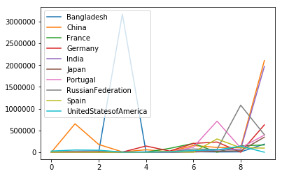

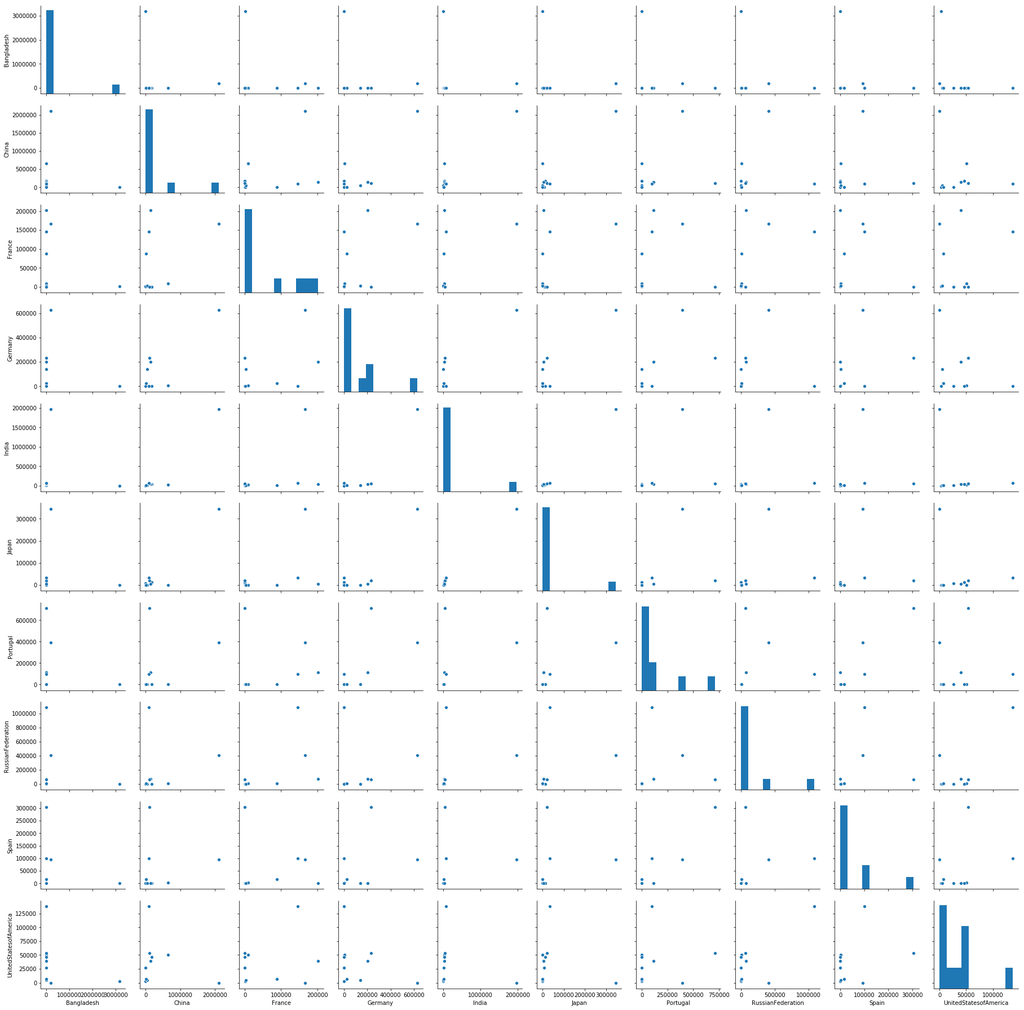

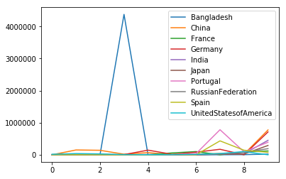

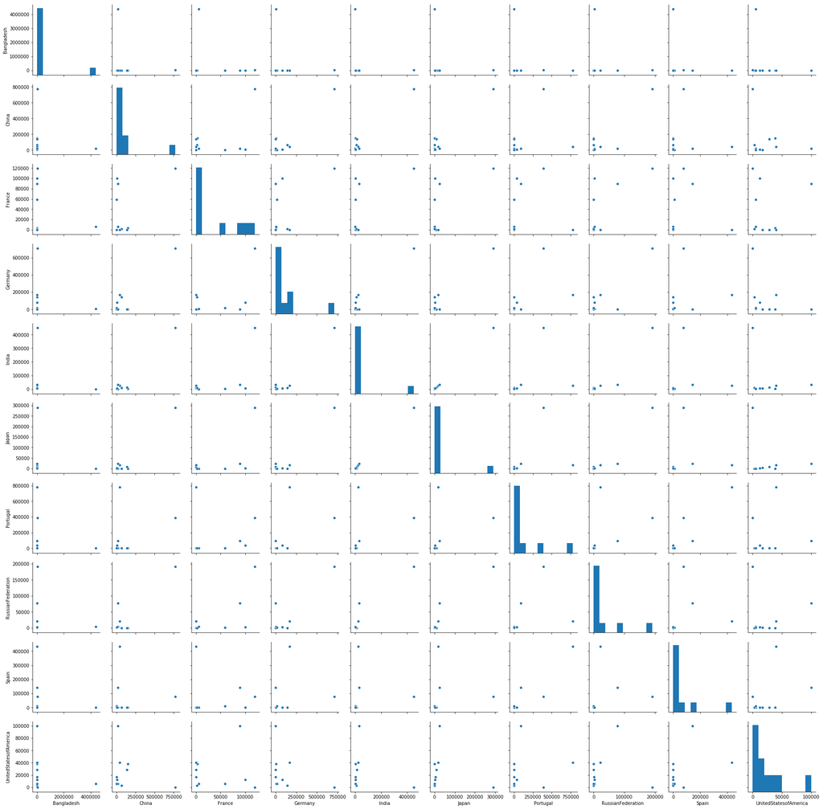

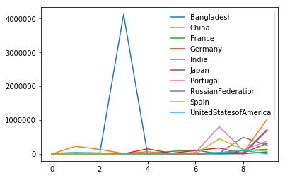

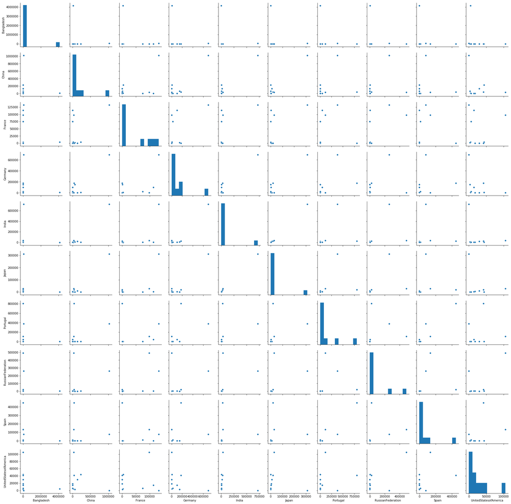

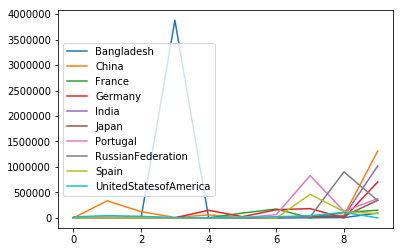

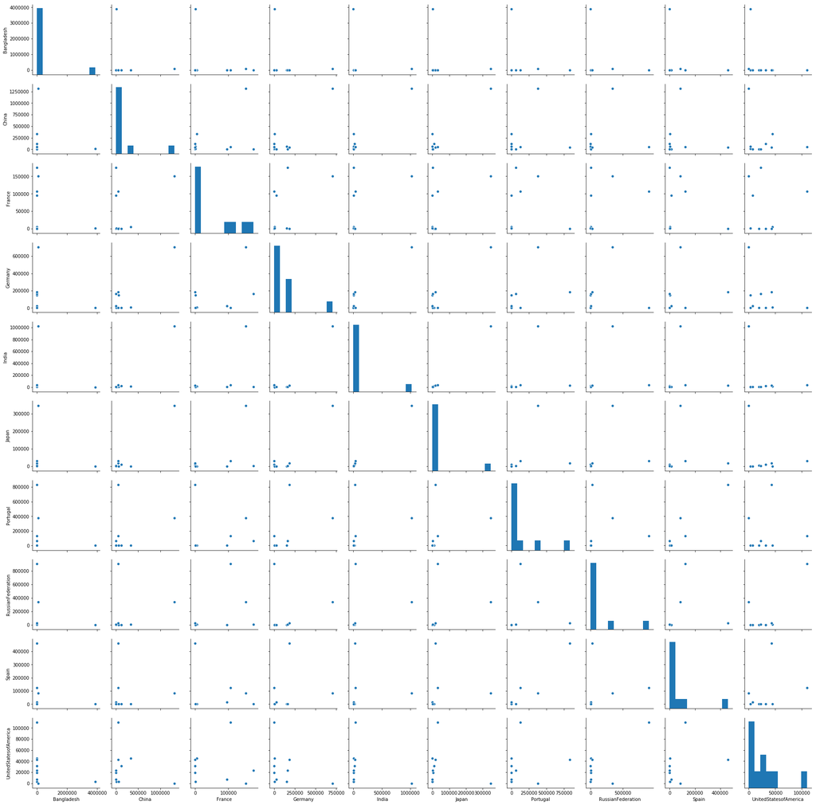

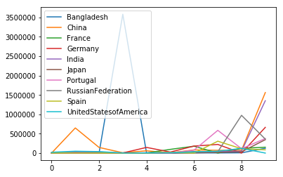

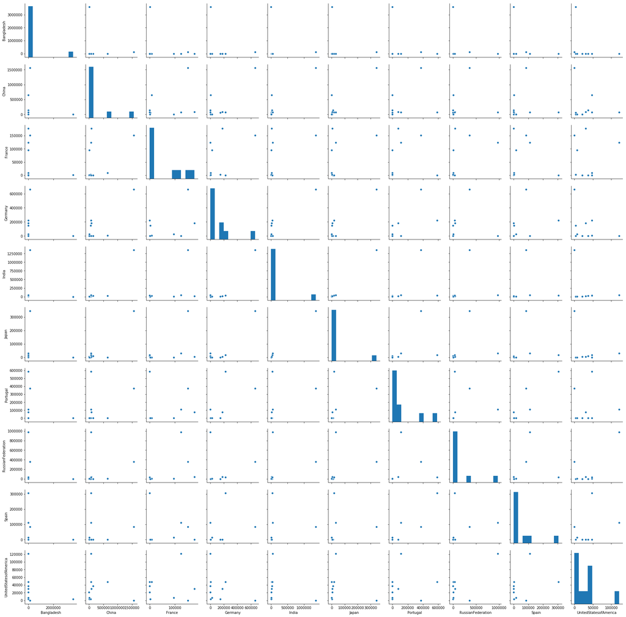

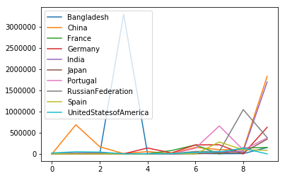

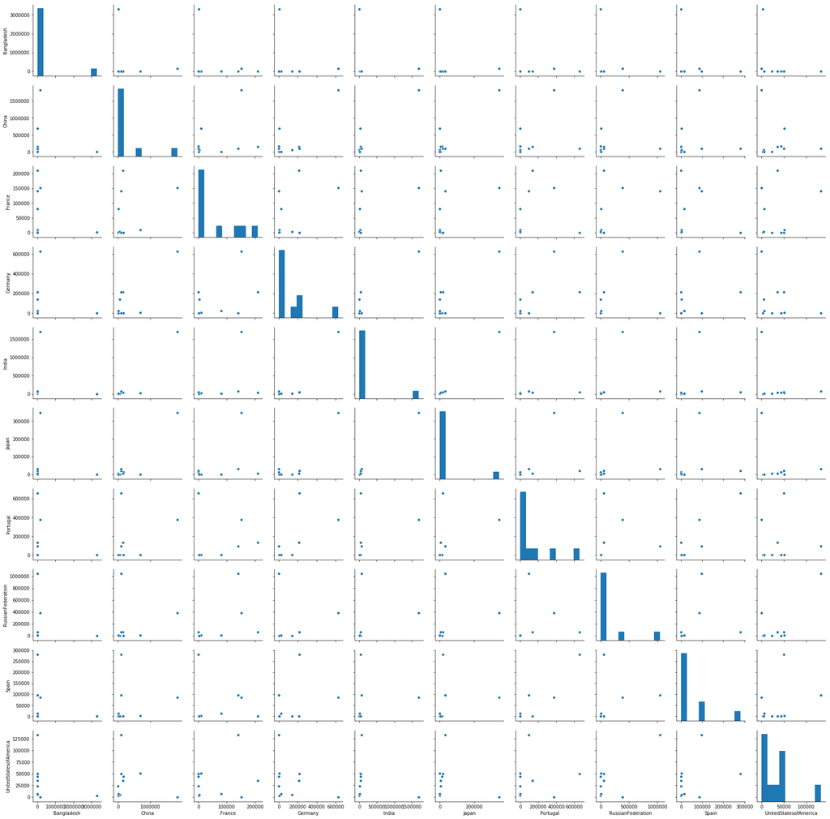

```python
filename=['2015','1990','1995','2000','2005','2010']
for i in filename:
    plt.figure()
    file=open('./data/imigra'+i+'.csv',"r")
    fileout=open('./data/imigra'+i+'pro.csv',"w")
    for line in file:
        out=line.replace(' ','')
        fileout.write(out)
    file.close()
    fileout.close()
    imigra=pd.read_csv('./data/imigra'+i+'pro.csv')
    imigra=imigra.fillna(0)
    imigra.plot()
    plt.savefig('./Picture/imigra'+i+'.png')
    sns.pairplot(imigra)
    plt.savefig('./Picture/imigra'+i+'sns.png')
    imigra.to_csv('./data/imigra'+i+'pro.csv')
```

## PartⅠC的移民情况分析

下图横坐标表示移民进入的国家,从左到右,编号从0-9,分别是: China Japan Bangladesh India Russian Federation Portugal Spain France Germany United States of America

[figure not shown]

## 下面的图片表示的是移民分布图

纵向表示移民进入的国家,横向表示移民移出的国家,纵坐标未标出,这里从下到上依次与横坐标相反,不再列出

[figure not shown]

figure: 1990年某些国家移民分布图

[figure not shown]

figure: 1995年某些国家移民分布图

[figure not shown]

figure: 2000年某些国家移民分布图

[figure not shown]

figure: 2005年某些国家移民分布图

[figure not shown]

figure: 2010年某些国家移民分布图

[figure not shown]

figure: 2015年某些国家移民分布图

# PartⅡ的解决问题思路分析

[figure not shown]

## 移民情况的马尔可夫链分析

这里采用最小二乘的闭式解预测解决马尔可夫状态转移矩阵的求解问题.

## 使用octave计算2055年的移民人数

```
A=load('imigra1990pro.csv')
B=load('imigra2000pro.csv');
D=A*pinv(B);
gg2055=D^5*A
gg2055(31:40,:)
csvwrite('~/gg2055.csv',ans)
```

\begin{equation} A=DB \tag{1} \label{eq1:q} \end{equation}\begin{equation} D=C^{10} \tag{2} \label{eq:q1} \end{equation}

\begin{equation} prediction_{2040,2045,2050,2055}=D^5 \times A \tag{3} \label{eq:my} \end{equation}

```python
import numpy as np
import pandas as pd
import pygal.maps.world
file=pd.read_csv('./data/gg2055.csv')
data=file.values
for i,name in enumerate(file.columns.tolist()):
    lanw = pygal.maps.world.World()
    lanw.title = 'Imigration all over the world'
    lanw.add('OC:'+name,{'bd':data[2,i],
                                     'jp':data[1,i],
                                     'cn':data[0,i],
                                     'in':data[3,i],
                                     'ru':data[4,i],
                                     'pt':data[5,i],
                                     'sp':data[6,i],
                                     'fr':data[7,i],
                                     'de':data[8,i],
                                     'us':data[9,i]})
    lanw.render_to_file('./Picture/imi2055'+str(i)+'.svg')
```

## 生成的国家移出人数

[figure not shown]

```python
from pandas import Series
from pandas import DataFrame
import pandas as pd
import matplotlib.pyplot as plt


class Gray_model:
    def __init__(self):
        self.a_hat = None
        self.x0 = None

    def fit(self,
            series=pd.Series(index=[1996, 1997, 1998, 1999], data=[1, 2, 3, 4])):
        """
        Series is a pd.Series with index as its date.
        :param series: pd.Series
        :return: None
        """
        self.a_hat = self._identification_algorithm(series.values)
        self.x0 = series.values[0]

    def predict(self, interval):
        result = []
        for i in range(interval):
            result.append(self.__compute(i))
        result = self.__return(result)
        return result

    def _identification_algorithm(self, series):
        B = np.array([[1] * 2] * (len(series) - 1))
        series_sum = np.cumsum(series)
        for i in range(len(series) - 1):
            B[i][0] = (series_sum[i] + series_sum[i + 1]) * (-1.0) / 2
        Y = np.transpose(series[1:])
        BT = np.transpose(B)
        a = np.linalg.inv(np.dot(BT, B))
        a = np.dot(a, BT)
        a = np.dot(a, Y)
        a = np.transpose(a)
        return a

    def score(self, series_true, series_pred, index):
        error = np.ones(len(series_true))
        relativeError = np.ones(len(series_true))
        for i in range(len(series_true)):
            error[i] = series_true[i] - series_pred[i]
            relativeError[i] = error[i] / series_pred[i] * 100
        score_record = {'GM': np.cumsum(series_pred),
                        '1—AGO': np.cumsum(series_true),
                        'Returnvalue': series_pred,
                        'Real_value': series_true,
                        'Error': error,
                        'RelativeError(%)': (relativeError)
                        }
        scores = DataFrame(score_record, index=index)
        return scores

    def __compute(self, k):
        return (self.x0 - self.a_hat[1] / self.a_hat[0]) * np.exp(-1 * self.a_hat[0] * k) + self.a_hat[1] / self.a_hat[
            0]

    def __return(self, series):
        tmp = np.ones(len(series))
        for i in range(len(series)):
            if i == 0:
                tmp[i] = series[i]
            else:
                tmp[i] = series[i] - series[i - 1]
        return tmp

    def evaluate(self, series_true, series_pred):
        scores = self.score(series_true, series_pred, np.arange(len(series_true)))

        error_square = np.dot(scores, np.transpose(scores))
        error_avg = np.mean(error_square)

        S = 0  # X0的关联度
        for i in range(1, len(series_true) - 1, 1):
            S += series_true[i] - series_true[0] + (series_pred[-1] - series_pred[0]) / 2
        S = np.abs(S)

        SK = 0  # XK的关联度
        for i in range(1, len(series_true) - 1, 1):
            SK += series_pred[i] - series_pred[0] + (series_pred[-1] - series_pred[0]) / 2
        SK = np.abs(SK)

        S_Sub = 0  # |S-SK|b
        for i in range(1, len(series_true) - 1, 1):
            S_Sub += series_true[i] - series_true[0] - (series_pred[i] - series_pred[0]) + ((series_true[-1] -
                                                                                             series_true[0]) - (
                                                                                            series_pred[i] -
                                                                                            series_pred[0])) / 2
        S_Sub = np.abs(S_Sub)

        T = (1 + S + SK) / (1 + S + SK + S_Sub)

        level = 0
        if T >= 0.9:
            level = 1
        # print ('精度为一级')
        elif T >= 0.8:
            level = 2
        # print ('精度为二级')
        elif T >= 0.7:
            level = 3
        # print ('精度为三级')
        elif T >= 0.6:
            level = 4
        # print ('精度为四级')
        return 1 - T, level

    def plot(self, series_true, series_pred, index):
        df = pd.DataFrame(index=index)
        df['Real'] = series_true
        df['Forcast'] = series_pred
        plt.figure()
        df.plot(figsize=(7, 5))
        plt.xlabel('year')
        plt.show()
```

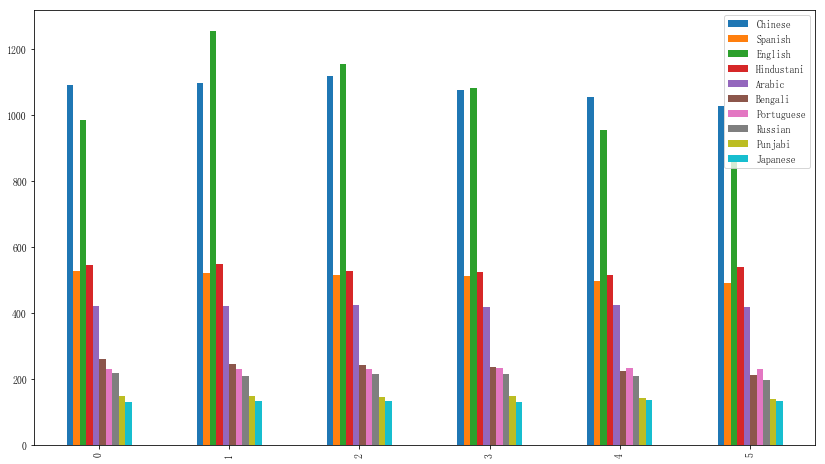

```python
df=pd.read_csv('./data/total.csv')

df.plot(kind='bar',figsize=(14,8))
plt.savefig('./picture/total.png')
```

```python
data=pd.read_csv('./data/total.csv')
pre=Gray_model()
file=open('./data/totalout55.csv','w')
for i in list(data.columns):
    pre.fit(series=data[i])
    line=pre.predict(55)
    for j in line:
        file.write(str(j)+',')
    file.write('\n')
file.close()
```

[figure not shown]

```python
data=pd.read_csv('./data/totalout55.csv')
data.plot()
plt.savefig('./picture/totalout55.png')
```

## 摘要

**Summary**

With the advent of increasingly accelerated globalization, the intricate geo-graphic distributions of languages start to hamper international business operations and cross-culture interactions. Comprehending the distribution dynamics has never been more crucial, yet projecting the distributions is difficult, particularly due to the complicated composition of speakers, the influence of various exogenous factors like the migration, government policies, economic development, and eagerness to learn. Therefore, we establish a new model to replace the projection model based purely on population, as it is not only inaccurate but also invalid faced with the scarcity of supporting data.

In Part I, our model focuses on native speakers and non-native speakers of lan-guages. We introduce the transition matrix **which comes from Markov Chain** to describe the transition between native speakers and non-native speakers of different languages, because the population growth of a language doesn’t solely come from natural births, but also migration and learning.**We also think GDP is another part of factor which may have influence on the language.**

In Part II, based on the requirement and the feature of service company, we adopt the AHP to help our client, a large multinational service corporation, select optimal location options for new offices.

Moreover, we build the cost-benefit analysis model to calculate the suitable number of offices that this company should build. Given the level of company’s profitability and cost, we set a new parameter, cost-profitability ratio. If the value of c-p ratio is less than 281, we think 6 offices should be built. If the value of this ratio is between 281 and 422, we think 5 offices should be built. If the value is between 422-527, 4 offices are best; if it is between 527 and 544, 3 office should be built; if>544, we should only maintain two offices.

Finally, we analyze the performance of our model and the sensitivity of our model, proving that our model is relatively stable for different parameters.

随着全球化进程的日益加快，错综复杂的语言地理分布开始阻碍国际商业运营和跨文化互动。理解分配动态从来没有变得更为重要，但是预测分配是困难的，特别是由于演讲者的复杂组成，移民、政府政策、经济发展和求知欲等各种外生因素的影响。因此，我们建立了一个新的模型来取代纯粹基于人口的投影模型，因为它不仅不准确，而且在缺乏支持数据的情况下也是无效的。  
在第一部分中，我们的模型侧重于母语人士和非母语人士的语言。我们引入转换矩阵来描述不同语言的母语者和非母语者之间的转换，因为一种语言的人口增长不仅来自于自然出生，还来自于迁移和学习。  
在第二部分中，我们根据服务公司的要求和特点，采用层次分析法帮助我们的客户，一家大型跨国服务公司，为新办公室选择最佳的位置选择。  
此外，我们还建立了成本效益分析模型，以计算该公司应建立的合适办公室数量。考虑到公司的盈利能力和成本水平，我们设置了一个新的参数，即成本盈利率。如果C-P比值小于281，我们认为应该建6个办事处。如果这个比率的值在281到422之间，我们认为应该建5个办公室。如果值在422-527之间，则最好是4个办公室；如果值在527-544之间，则应建造3个办公室；如果值大于544，则只应维护两个办公室。  
最后，我们分析了我们的模型的性能和模型的灵敏度，证明我们的模型在不同参数下相对稳定。